# Acute vs. culture patchseq comparison

Jeremy Miller

April 29, 2023

This notebook performs some comparisons for the acute vs. culture study on GABAergic interneurons.

If needed set the working directory: (e.g., `setwd("PATH_TO_DIRECTORY/patchseq_human_L23")`).

## Prepare the data

First load the required libraries and options and set directory locations. Note: that you will need to have Seurat version 4.0.6 installed for this to produce the correct results. Uncomment the line below to install that version.

```r
# You need an older version of Seurat
#remotes::install_version("Seurat", version = "4.0.6")

## Load libraries
suppressPackageStartupMessages({
  library(Matrix)
  library(matrixStats)
  library(Seurat)
  library(scrattch.vis)
  library(scrattch.io)
  library(feather)
  library(VENcelltypes) # for sex and mito genes
  library(scrattch.hicat) # for get_cl_XXX
  library(mfishtools) # subsampleCells
  library(dplyr)
  library(randomForest)
  library(WGCNA)
})
options(stringsAsFactors=FALSE)
options(future.globals.maxSize=8*1024^3)
```

Next, load the all the relevant data, which was calculated in a previous manuscript script.

```r
load("complete_facs_data_sets.RData")
```

Load patch-seq meta-data and data.

```r
load("complete_patchseq_data_sets.RData") # Includes datPatch, annoPatch, metaPatch

## Revert names to original Hodge et al names
a <- metaPatch$topLeaf_label
metaPatch$topLeaf_label <- as.character(lapply(strsplit(a," \\("),function(x) return(x[[1]][1])))
annoPatch$topLeaf_label <- metaPatch$topLeaf_label  # To avoid using the wrong cell type assignment below

## Update the morpho call on one cell
metaPatch$morpho_call[metaPatch$spec_id==893655882] = "SMC"
metaPatch$morpho_call[metaPatch$morpho_call=="SMC"] = "Sparse SST"
```

Let’s do some pre-processing to exclude genes that are enriched in glial clusters or that are exceptionally higher in dissociated nuclei (still called “FACS” for convenience) relative to Patch-seq data. We also want to exclude sex and mitochondrial from consideration as markers.

```r
## Cells to keep
kpClusts <- names(table(metaPatch$topLeaf_label)[table(metaPatch$topLeaf_label)>=10]) #c("Inh L2-4 PVALB WFDC2","Inh L2-4 SST FRZB")
kpMTG    <- is.element(annoMTG_all$cluster_label,kpClusts)&subsampleCells(annoMTG_all$cluster_label,100)
datMTG   <- datMTG_all[,kpMTG]

# First exclude mitochondrial and sex genes
isExclude <- sort(unique(c(sex_genes,mito_genes)))
excludeGn <- is.element(rownames(datPatch),isExclude)

# Second find glial genes and exclude these from consideration.
clMTG   = factor(annoMTG_all$cluster_label)
names(clMTG) <- colnames(datMTG_all)
medians = get_cl_medians(datMTG_all,clMTG)
isUsed  = unique(as.character(clMTG))
isGlia  = isUsed[!(grepl("Exc",isUsed)|grepl("Inh",isUsed))]
isUsed  = kpClusts # setdiff(isUsed,isGlia)

maxUsed = apply(medians[,isUsed],1,max)
maxGlia = apply(medians[,isGlia],1,max)
glialGn = maxGlia>maxUsed     # Exclude genes with maximal median expression in glia

# Third, exclude genes with average expression at least four-fold higher in either FACS or patch-seq
platformGn = abs(rowMeans(datMTG)-rowMeans(datPatch))>=2

# Finally, only keep genes that are expressed in both FACS and Patch-seq (log2(CPM+0)>0 in 1% of the cells)
expressedGn = (rowSums(datMTG>=1)>(0.01*dim(datMTG)[2]))&(rowSums(datPatch>=1)>(0.01*dim(datPatch)[2]))

keepGenes <- (!(excludeGn|glialGn|platformGn))&(expressedGn)
mean(keepGenes)
```

```
[1] 0.4303216
```

Note that we will only use this as a filter for some analyses.

## Immune signatures in patch-seq data

Let’s start off unbiased clustering of cultured cells.

```r
metaPatch$condition[is.na(metaPatch$condition)] = "acute"
patch.metadata <- data.frame( celltype = metaPatch$topLeaf_label, condition = metaPatch$condition,
                              subclass = metaPatch$subclass_label,
                              source = c("AIBS","other")[grepl("x",metaPatch$cell_specimen_project)+1])
rownames(patch.metadata) <- colnames(datPatch)
patch   <- CreateSeuratObject(counts = datPatch, meta.data = patch.metadata)
culture <- patch[,metaPatch$condition!="acute"]
culture <- FindVariableFeatures(culture,verbose=FALSE)

pcs_patch <- 20
res_patch <- 0.001
culture <- ScaleData(culture, verbose = FALSE)
culture <- RunPCA(culture, npcs = pcs_patch, verbose = FALSE)
culture <- RunUMAP(culture, reduction = "pca", dims = 1:pcs_patch, verbose = FALSE)
culture <- FindNeighbors(culture, dims = 1:2, verbose = FALSE,reduction="umap")
```

```r
culture <- FindClusters(culture, resolution = res_patch, verbose=FALSE)

p1 <- DimPlot(culture, reduction = "umap", group.by = "celltype")
```

|  | t | l | b | r |
| --- | --- | --- | --- | --- |
| 1: | 1 | 1 | 1 | 1 |

```r
p2 <- DimPlot(culture, reduction = "umap")
```

|  | t | l | b | r |
| --- | --- | --- | --- | --- |
| 1: | 1 | 1 | 1 | 1 |

```r
p3 <- DimPlot(culture, reduction = "umap", group.by = "subclass")
```

|  | t | l | b | r |
| --- | --- | --- | --- | --- |
| 1: | 1 | 1 | 1 | 1 |

```r
p4 <- DimPlot(culture, reduction = "umap", group.by = "source")
```

|  | t | l | b | r |
| --- | --- | --- | --- | --- |
| 1: | 1 | 1 | 1 | 1 |

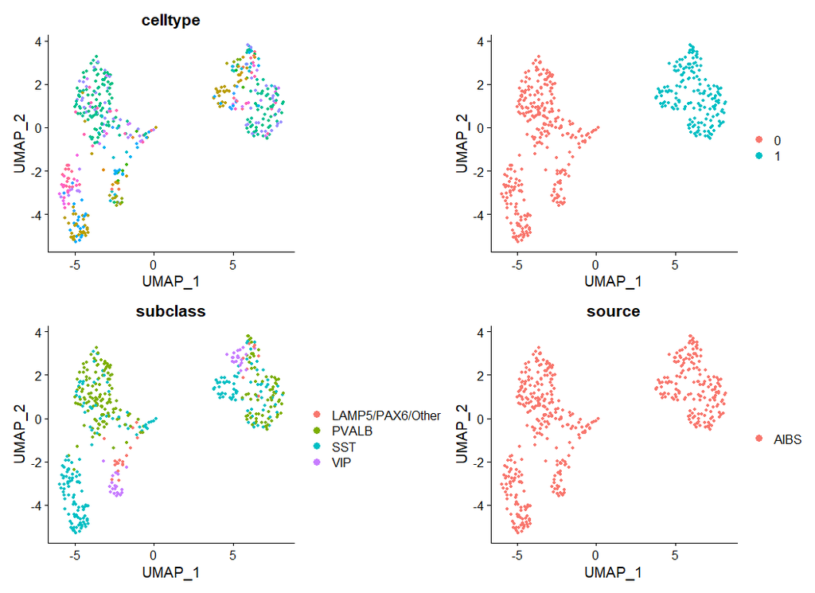

```r
print((p1+NoLegend())+p2+p3+p4)
```

There is a source of variation more prevalent than subclass/cell type. What is it? Let’s perform differential expression between cluster 0 and 1 to find out.

```r
(culture_DEX <- FindMarkers(culture, min.pct = 0.5, logfc.threshold = 4, ident.1="0", ident.2="1", verbose=FALSE))
```

|  | p_val | avg_log2FC | pct.1 | pct.2 | p_val_adj |
| --- | --- | --- | --- | --- | --- |
| CD53 | 6.360307e-82 | -6.191481 | 0.126 | 0.988 | 3.198026e-77 |
| CCRL2 | 6.000173e-80 | -7.405118 | 0.044 | 0.930 | 3.016947e-75 |
| OLR1 | 6.088460e-80 | -7.354261 | 0.122 | 0.971 | 3.061339e-75 |
| C1QC | 1.215243e-79 | -6.689009 | 0.194 | 0.994 | 6.110361e-75 |
| SYNGR2 | 1.287283e-78 | -5.338839 | 0.180 | 0.994 | 6.472588e-74 |
| SRGN | 3.038239e-78 | -7.366476 | 0.255 | 0.994 | 1.527657e-73 |
| CCR1 | 9.367402e-78 | -7.181347 | 0.058 | 0.913 | 4.710024e-73 |
| SLC15A3 | 5.378300e-77 | -4.206622 | 0.092 | 0.948 | 2.704263e-72 |
| LILRB4 | 2.033974e-76 | -6.692552 | 0.238 | 0.988 | 1.022703e-71 |
| MS4A7 | 3.457475e-76 | -5.448675 | 0.241 | 0.994 | 1.738453e-71 |

[output cut: 259 more lines]

These top genes are all immune related, and likely represent microglial contaminated as reported in (Shreejoy paper). Let’s use this gene set as a filter for dividing culture and acute cells into immune and non-immune groups.

```r
res_patch <- 0.1
VariableFeatures(culture) <- rownames(culture_DEX)
culture <- ScaleData(culture, verbose = FALSE)
culture <- RunPCA(culture, npcs = pcs_patch, verbose = FALSE)
culture <- RunUMAP(culture, reduction = "pca", dims = 1:pcs_patch, verbose = FALSE)
culture <- FindNeighbors(culture, dims = 1:2, verbose = FALSE,reduction="umap")
```

```r
culture <- FindClusters(culture, resolution = res_patch, verbose=FALSE)

acute <- patch[,metaPatch$condition=="acute"]
VariableFeatures(acute) <- rownames(culture_DEX)
acute <- ScaleData(acute, verbose = FALSE)
acute <- RunPCA(acute, npcs = pcs_patch, verbose = FALSE)
acute <- RunUMAP(acute, reduction = "pca", dims = 1:pcs_patch, verbose = FALSE)
acute <- FindNeighbors(acute, dims = 1:2, verbose = FALSE,reduction="umap")
```

```r
acute <- FindClusters(acute, resolution = res_patch, verbose=FALSE)

p1 <- FeaturePlot(culture,"CD53")
```

|  | t | l | b | r |
| --- | --- | --- | --- | --- |
| 1: | 1 | 1 | 1 | 1 |

```r
p2 <- DimPlot(culture, reduction = "umap")
```

|  | t | l | b | r |
| --- | --- | --- | --- | --- |
| 1: | 1 | 1 | 1 | 1 |

```r
p3 <- FeaturePlot(acute,"CD53")
```

|  | t | l | b | r |
| --- | --- | --- | --- | --- |
| 1: | 1 | 1 | 1 | 1 |

```r
p4 <- DimPlot(acute, reduction = "umap")
```

|  | t | l | b | r |
| --- | --- | --- | --- | --- |
| 1: | 1 | 1 | 1 | 1 |

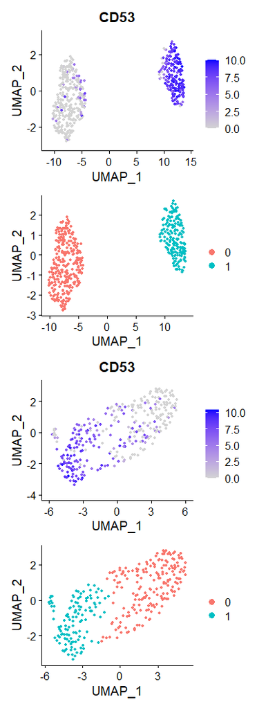

```r
print(p1+p2+p3+p4)
```

There is a clear separation by immune signature in the cultured cells, but this look more gradient in acute cells, although the same signature appears to work for both, and in both cases cluster=1 corresponds to the immune signature. Add this metadata to the patch-seq Seurat object and metadata.

```r
metaPatch$isImmune <- c(Idents(culture),Idents(acute))[colnames(datPatch)]==1
metaPatch$condition2 <- metaPatch$condition
metaPatch$condition2[metaPatch$isImmune] <- paste0(metaPatch$condition2[metaPatch$isImmune],"_immune")
patch <- AddMetaData(patch,metaPatch$condition2,"condition2")
```

Let’s see how this splits out by cell type and subclass.

```r
ct <- names(table(patch$celltype))[table(patch$celltype)>=10]
tab <- table(patch$celltype,patch$condition2)[ct,]
ord <- order(rowSums(tab[,c(1,3)])/rowSums(tab[,c(2,4)]))
tab[ord,]
```

```
                        acute acute_immune culture culture_immune
  Inh L2-5 PVALB SCUBE3     1            2       6              7
  Inh L5-6 SST TH           1            0       6              9
  Inh L4-5 PVALB MEPE      13           17      23             27
  Inh L3-6 SST HPGD         1            0       4              6
  Inh L2-4 SST FRZB         4            4      36             32
  Inh L1-2 PAX6 CDH12       5            3       1              2
  Inh L1-3 SST CALB1        5            5      31             23
  Inh L1-3 VIP CCDC184      5            5       3              1
  Inh L4-5 SST STK32A       0            3      10              4
  Inh L1-3 PAX6 SYT6        7            1       4              6
  Inh L2-6 LAMP5 CA1       16           13      10              3
  Inh L5-6 SST MIR548F2     5            3      13              6
  Inh L2-4 PVALB WFDC2     48           31      65             24
  Inh L1-4 LAMP5 LCP2      12            6       5              2
  Inh L4-6 PVALB SULF1     11            5      10              4
  Inh L1-3 VIP ADAMTSL1     4            1       4              1
  Inh L2-3 VIP CASC6       11            2       1              1
  Inh L3-5 SST ADGRG6       6            1      21              3
  Inh L5-6 SST KLHDC8A      1            0      10              1
```

```r
table(patch$subclass,patch$condition2)
```

```
                   acute acute_immune culture culture_immune
  LAMP5/PAX6/Other    39           26      19              8
  PVALB               79           58     119             71
  SST                 21           17     130             79
  VIP                 49           23      20             20
```

There is not an obvious cell type relationship in acute vs. culture: immune signature and non-immune signature cells are found in most types with the possible exception of a few SST and VIP types that tend to have very few cells with immune signatures.

## Gene signatures of culture (and immune response)

Our main interest is to understand how gene expression may change in culture. Given the large gene expression signature of this immune response, we have to account for it if we want to understand genes differentially expressed in culture. Here we explicitly ask: What are the top DEX genes between these groups? Since Pvalb interneurons are relatively homogeneous (as compared to other subclasses) and are well-represented in all four conditions, we will focus initially only on Pvalb types.

```r
test.patch     <- patch[,patch$subclass=="PVALB"]
Idents(test.patch) <- test.patch$condition2
acute_immune   <- FindMarkers(test.patch, min.pct = 0.25, logfc.threshold = 2,
                              ident.1="acute_immune", ident.2="acute", verbose=FALSE)
```

```r
culture_immune <- FindMarkers(test.patch, min.pct = 0.25, logfc.threshold = 2,
                              ident.1="culture_immune", ident.2="culture", verbose=FALSE)
```

```r
acute_culture  <- FindMarkers(test.patch, min.pct = 0.25, logfc.threshold = 2,
                              ident.1="acute", ident.2="culture", verbose=FALSE)
```

```r
acutei_culturei<- FindMarkers(test.patch, min.pct = 0.25, logfc.threshold = 2,
                              ident.1="acute_immune", ident.2="culture_immune", verbose=FALSE)
```

```r
# Rename columns
colnames(acute_immune)    <- c("pval_ai_over_a","avg_logFC_ai_over_a","pct_acute_immune","pct_acute","pval_adj_ai_over_a")
colnames(culture_immune)  <- c("pval_ci_over_c","avg_logFC_ci_over_c","pct_culture_immune","pct_culture","pval_adj_ci_over_c")
colnames(acute_culture)   <- c("pval_a_over_c","avg_logFC_a_over_c","pct_acute","pct_culture","pval_adj_a_over_c")
colnames(acutei_culturei) <- c("pval_ai_over_ci","avg_logFC_ai_over_ci","pct_acute_immune","pct_culture_immune","pval_adj_ai_over_ci")

data.frame(head(acutei_culturei,50))
```

|  | pval_ai_over_ci | avg_logFC_ai_over_ci | pct_acute_immune | pct_culture_immune | pval_adj_ai_over_ci |
| --- | --- | --- | --- | --- | --- |
| CTSD | 7.342927e-22 | -6.343019 | 0.948 | 1.000 | 3.692097e-17 |
| DLX6-AS1 | 9.894878e-22 | -10.187720 | 0.586 | 1.000 | 4.975244e-17 |
| TIMP1 | 1.007292e-21 | -5.822651 | 0.328 | 1.000 | 5.064764e-17 |
| GPNMB | 1.055192e-21 | -7.216857 | 0.345 | 0.986 | 5.305611e-17 |
| PSAP | 1.674699e-21 | -4.522217 | 1.000 | 1.000 | 8.420552e-17 |
| IFI30 | 2.915494e-21 | -6.085457 | 0.793 | 1.000 | 1.465940e-16 |
| APOE | 5.686504e-21 | -4.550817 | 1.000 | 1.000 | 2.859231e-16 |
| PLD3 | 7.117661e-21 | -3.368824 | 0.966 | 1.000 | 3.578831e-16 |
| TGFBI | 1.289807e-20 | -6.817029 | 0.103 | 0.958 | 6.485278e-16 |
| GDF15 | 4.419130e-20 | -12.012607 | 0.000 | 0.873 | 2.221983e-15 |

[output cut: 40 more lines]

```r
acute_immune$gene    <- rownames(acute_immune)
culture_immune$gene  <- rownames(culture_immune)
acute_culture$gene   <- rownames(acute_culture)
acutei_culturei$gene <- rownames(acutei_culturei)
```

Which genes are differentially expressed between acute and culture in both the immune and non-immune groups?

```r
dex_genes <- acute_immune %>%
  full_join(culture_immune, by="gene")  %>%
  full_join(acute_culture, by="gene")  %>%
  full_join(acutei_culturei, by="gene")
write.csv(dex_genes,"immune_and_culture_gene_sets.csv")

is_immune <- sort(intersect(rownames(culture_immune)[culture_immune$avg_logFC_ci_over_c>0],
                            rownames(acute_immune)[acute_immune$avg_logFC_ai_over_a>0]))
is_acute  <- sort(intersect(rownames(acute_culture)[acute_culture$avg_logFC_a_over_c>0],
                            rownames(acutei_culturei)[acutei_culturei$avg_logFC_ai_over_ci>0]))
is_culture<- sort(intersect(rownames(acute_culture)[acute_culture$avg_logFC_a_over_c<0],
                            rownames(acutei_culturei)[acutei_culturei$avg_logFC_ai_over_ci<0]))
write(is_acute,"is_acute_pvalb.txt")
write(is_culture,"is_culture_pvalb.txt")
write(is_immune,"is_immune_pvalb.txt")
```

### Plot the top genes

In this section we are going to plot the top DEX genes from the patch-seq data from the lists above. It may make more sense to treat this as a replication set for 10X data, but let’s see how things look. First let’s look at the top immune genes

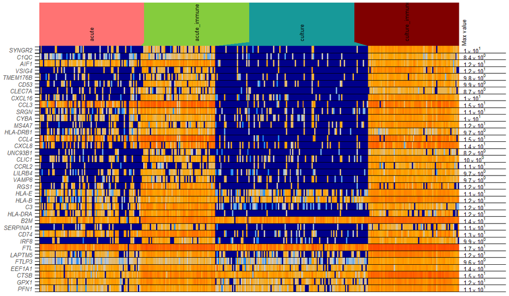

```r
anno <- test.patch@meta.data
anno <- scrattch.io::annotate_factor(anno,"condition") # for later
anno <- scrattch.io::annotate_factor(anno,"condition2")
anno$condition2_color[anno$condition2_color=="#0066"] = "#006600"
anno$condition2_color[anno$condition2_color=="#8000"] = "#800000" # Error correction... I fixed this before but need to find how
data <- as.matrix(test.patch@assays$RNA@counts)
data_df <- cbind(sample_name = colnames(data),as.data.frame(t(data)))
anno$sample_name <- data_df$sample_name

gnTmp <- unique(c(rownames(culture_immune)[1:20],rownames(acute_immune)[1:20]))
scrattch.vis::sample_heatmap_plot(data_df, anno, genes = gnTmp, grouping = "condition2", log_scale = TRUE, font_size = 10, label_height = 15)
```

Next, let’s look at the top acute- and culture-specific genes.

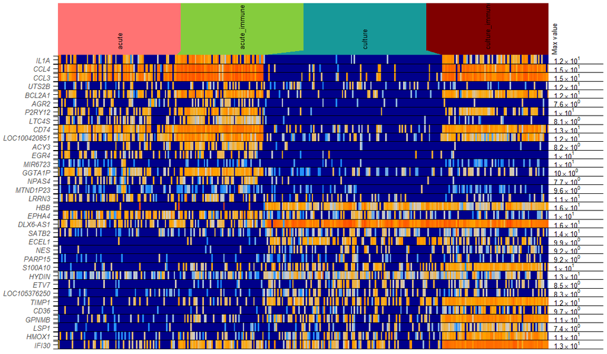

```r
gnTmp <- unique(c(intersect(rownames(acute_culture[order(-acute_culture[,2]),]),is_acute)[1:10],
                   intersect(rownames(acutei_culturei[order(-acutei_culturei[,2]),]),is_acute)[1:10],
                   intersect(rownames(acute_culture[order(acute_culture[,2]),]),is_culture)[1:10],
                   intersect(rownames(acutei_culturei[order(acutei_culturei[,2]),]),is_culture)[1:10]))
scrattch.vis::sample_heatmap_plot(data_df, anno, genes = gnTmp, grouping = "condition2", log_scale = TRUE, font_size = 10, label_height = 15)
```

Many of these top genes also appear to have a pretty strong immune effect. What if we discard genes with immune effects?

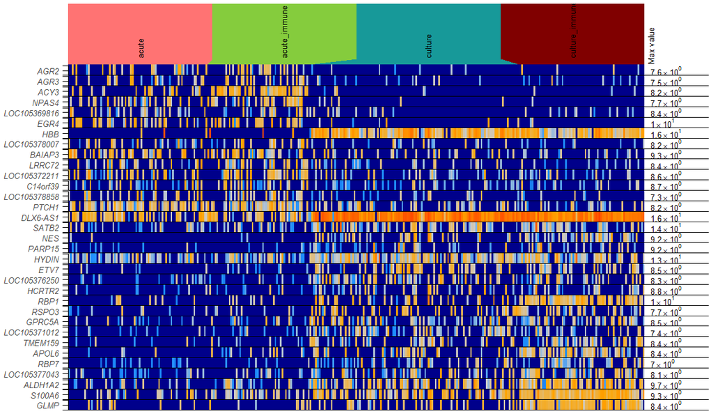

```r
gnTmp <- setdiff(c(intersect(rownames(acute_culture[order(-acute_culture[,2]),]),is_acute)[1:25],
                   intersect(rownames(acutei_culturei[order(-acutei_culturei[,2]),]),is_acute)[1:25],
                   intersect(rownames(acute_culture[order(acute_culture[,2]),]),is_culture)[1:25],
                   intersect(rownames(acutei_culturei[order(acutei_culturei[,2]),]),is_culture)[1:25]),
                 c(rownames(culture_immune),rownames(acute_immune)))
scrattch.vis::sample_heatmap_plot(data_df, anno, genes = gnTmp, grouping = "condition2", log_scale = TRUE, font_size = 10, label_height = 15)
```

I’m not sure what these genes are, but they look somewhat reasonable. We may want to compare with 10x data at some point.

Let’s plot some immediate early genes and HLA immune genes for a sanity check.

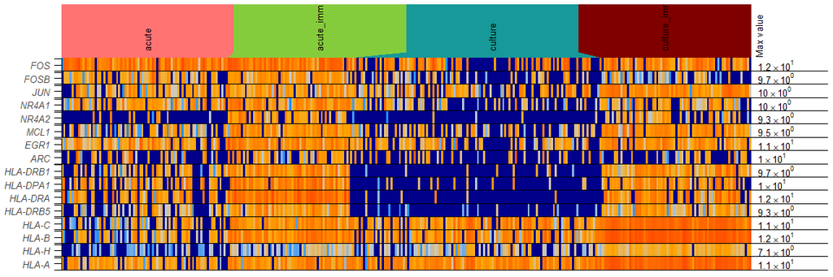

```r
iegs <- c("FOS", "FOSB", "JUN", "NR4A1", "NR4A2", "MCL1", "EGR1", "ARC")
hlas <- c("HLA-DRB1","HLA-DPA1","HLA-DRA","HLA-DRB5", "HLA-C","HLA-B","HLA-H","HLA-A")
gnTmp <- c(iegs,hlas)
scrattch.vis::sample_heatmap_plot(data_df, anno, genes = gnTmp, grouping = "condition2", log_scale = TRUE, font_size = 10, label_height = 20)
```

Many of these genes show an immune signature, as expected.

Finally, let’s output a UMAP showing these results.

```r
subclass <- rep("LAMP5/PAX6",length(metaPatch$topLeaf_label))
for (nm in c("VIP","SST","PVALB"))
  subclass[grepl(nm,metaPatch$topLeaf_label)] = nm
patch.metadata2 <- data.frame( celltype = metaPatch$topLeaf_label,
                               subclass = subclass, condition = metaPatch$condition,
                               condition2=metaPatch$condition2)
rownames(patch.metadata2) <- colnames(datPatch)
patch <- CreateSeuratObject(counts = datPatch, meta.data = patch.metadata2)
VariableFeatures(patch) <- c(is_acute[1:50],is_culture[1:50],is_immune[1:50]) # This variable holds the immune genes identified above

pcs_patch <- 20
patch <- ScaleData(patch, verbose = FALSE)
patch <- RunPCA(patch, npcs = pcs_patch, verbose = FALSE)
patch <- RunUMAP(patch, reduction = "pca", dims = 1:pcs_patch, verbose = FALSE)

p1 <- DimPlot(patch, reduction = "umap", group.by = "celltype")
```

|  | t | l | b | r |
| --- | --- | --- | --- | --- |
| 1: | 1 | 1 | 1 | 1 |

```r
p2 <- DimPlot(patch, reduction = "umap", group.by = "subclass")
```

|  | t | l | b | r |
| --- | --- | --- | --- | --- |
| 1: | 1 | 1 | 1 | 1 |

```r
p3 <- DimPlot(patch, reduction = "umap", group.by = "condition2")
```

|  | t | l | b | r |
| --- | --- | --- | --- | --- |
| 1: | 1 | 1 | 1 | 1 |

```r
print((p1+NoLegend())+p2+p3)

pdf("pre_integration_UMAP.pdf", height = 4, width = 14)
```

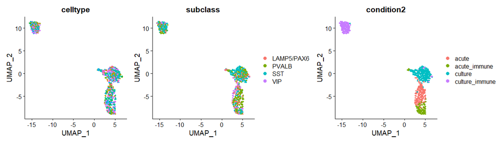

```r
print((p1+NoLegend())+p2+p3)
dev.off()
```

## Identify acute vs. culture genes

Let’s explicitly perform a linear model to identify genes associated with culture after accounting for subclass (after changing SST FRZB to PVALB) and immune signature.

```r
tmpPatch <- metaPatch[,c("condition","isImmune","subclass_label")]
tmpPatch$subclass_label[metaPatch$topLeaf_label=="Inh L2-4 SST FRZB"] = "PVALB"

lm_pval_apply <- function(x){
  dat   <- data.frame(tmpPatch,expression = x)
  lmOut <- lm(expression~condition+isImmune+subclass_label+condition*isImmune, data = dat)
  summary(lmOut)$coefficients[2:dim(summary(lmOut)$coefficients)[1],4]
}

cn <- c("condition","isImmune","subclass_label")
lm_pval <- apply(datPatch[keepGenes,],1,lm_pval_apply)
lm_pval_adjust <- apply(lm_pval,2,p.adjust)  # FDR corrected
(topACgenes <- data.frame(t(lm_pval_adjust)[order(lm_pval_adjust[1,]),]))
```

|  | conditionculture | isImmuneTRUE | subclass_labelPVALB | subclass_labelSST | subclass_labelVIP | conditionculture.isImmuneTRUE |
| --- | --- | --- | --- | --- | --- | --- |
| ECEL1 | 6.364382e-33 | 7.688811e-01 | 2.232221e-01 | 5.666143e-01 | 5.890083e-01 | 2.312486e-02 |
| LOC100996251 | 7.466752e-24 | 1.000000e+00 | 6.368731e-01 | 1.000000e+00 | 1.000000e+00 | 1.454609e-04 |
| GUCA1B | 2.243055e-23 | 9.056465e-02 | 2.917614e-02 | 5.075895e-01 | 5.075895e-01 | 9.067027e-05 |
| SPOCD1 | 3.137492e-23 | 1.000000e+00 | 1.000000e+00 | 1.000000e+00 | 1.000000e+00 | 1.000000e+00 |
| TEAD4 | 5.544355e-23 | 2.302772e-01 | 1.000000e+00 | 1.000000e+00 | 3.631277e-01 | 1.470895e-02 |
| BEST4 | 2.841111e-22 | 1.000000e+00 | 3.876194e-04 | 7.690454e-01 | 1.000000e+00 | 3.493118e-03 |
| LOC391359 | 4.348545e-22 | 6.622546e-01 | 3.218931e-02 | 6.622546e-01 | 1.663542e-02 | 2.883264e-07 |
| TMEM191A | 7.176832e-21 | 3.646376e-03 | 4.782274e-02 | 9.735860e-01 | 5.944583e-01 | 3.954401e-03 |
| LOC102723370 | 1.918892e-19 | 1.580413e-02 | 9.986780e-06 | 1.358619e-04 | 5.526146e-02 | 5.645530e-08 |
| CASC15 | 3.912792e-19 | 1.662982e-01 | 3.745466e-02 | 1.662982e-01 | 3.745466e-02 | 9.063173e-06 |

[output cut: 990 more lines]

Add fold change in acute vs. culture as well as whether or not it’s an channel gene. We used a curated set of voltage gated ion channels for this analysis.

```r
channels <- read.csv("vgic_genes.csv")$HGNC.symbol
exprAC <- findFromGroups(t(datPatch[rownames(topACgenes),]),metaPatch$condition)
topACgenes$isChannel <- is.element(rownames(topACgenes),channels)
topACgenes <- cbind(topACgenes,exprAC)
topACgenes$FC <- topACgenes[,"culture"] - topACgenes[,"acute"]
write.csv(topACgenes,"top_acute_culture_genes.csv")
filteredACgenes <- topACgenes[(topACgenes$isChannel),]
(filteredACgenes <- filteredACgenes[order(-log(filteredACgenes$conditionculture)*sign(filteredACgenes$FC)),])
```

|  | conditionculture | isImmuneTRUE | subclass_labelPVALB | subclass_labelSST | subclass_labelVIP | conditionculture.isImmuneTRUE | isChannel | acute | culture | FC |
| --- | --- | --- | --- | --- | --- | --- | --- | --- | --- | --- |
| KCNG2 | 3.127567e-08 | 2.707353e-02 | 1.931702e-01 | 2.755894e-03 | 7.028410e-04 | 1.681947e-01 | TRUE | 3.8010431 | 2.0475600 | -1.753483132 |
| CATSPER3 | 1.443922e-04 | 1.000000e+00 | 7.480744e-01 | 1.000000e+00 | 1.000000e+00 | 1.000000e+00 | TRUE | 2.6052942 | 1.6428249 | -0.962469337 |
| KCNT2 | 2.130451e-04 | 9.868664e-02 | 1.654658e-25 | 6.502488e-27 | 2.861086e-11 | 1.577739e-01 | TRUE | 3.8766967 | 3.2216871 | -0.655009559 |
| KCNJ3 | 2.288490e-04 | 1.031822e-03 | 3.028114e-02 | 2.229034e-02 | 2.290918e-02 | 7.581539e-02 | TRUE | 6.4551729 | 5.0607594 | -1.394413483 |
| KCNA3 | 2.332080e-04 | 4.038644e-01 | 4.060913e-03 | 3.628379e-10 | 4.060913e-03 | 2.185969e-01 | TRUE | 4.3093535 | 3.3552930 | -0.954060450 |
| CACNA1G | 3.640000e-04 | 9.071124e-02 | 2.125597e-02 | 4.272750e-02 | 1.635043e-03 | 9.071124e-02 | TRUE | 4.5643157 | 3.3372592 | -1.227056517 |
| KCNC2 | 4.219515e-04 | 1.371907e-03 | 5.018052e-13 | 1.713331e-01 | 4.895122e-01 | 7.670678e-04 | TRUE | 8.7640424 | 7.8336687 | -0.930373675 |
| TRPV6 | 3.702322e-03 | 1.000000e+00 | 1.000809e-03 | 3.963781e-04 | 1.000000e+00 | 8.622692e-01 | TRUE | 0.9739361 | 0.5970717 | -0.376864384 |
| KCNJ4 | 3.815006e-03 | 4.966721e-01 | 4.213556e-03 | 1.000000e+00 | 1.300370e-01 | 1.000000e+00 | TRUE | 1.5318002 | 1.0388375 | -0.492962704 |
| TRPV4 | 6.338368e-03 | 1.000000e+00 | 3.499464e-02 | 9.746162e-01 | 1.000000e+00 | 1.376723e-02 | TRUE | 1.6225136 | 1.3948143 | -0.227699272 |

[output cut: 105 more lines]

Now plot some of the top genes

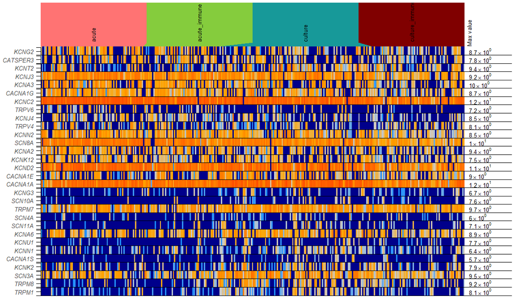

```r
gnTmp <- rownames(filteredACgenes)[c(1:15,101:115)]
scrattch.vis::sample_heatmap_plot(data_df, anno, genes = gnTmp, grouping = "condition2", log_scale = TRUE, font_size = 10, label_height = 15)
```

This doesn’t look great. Let’s restrict the analysis to only “Inh L2-4 PVALB WFDC2” as the most common type.

```r
kpPatch  <- metaPatch$cluster_label=="Inh L2-4 PVALB WFDC2"
tmpPatch <- metaPatch[,c("condition","isImmune")]

lm_pval_apply <- function(x){
  dat   <- data.frame(tmpPatch[kpPatch,],expression = x)
  lmOut <- lm(expression~condition+isImmune+condition*isImmune, data = dat)
  summary(lmOut)$coefficients[2:dim(summary(lmOut)$coefficients)[1],4]
}

keepGenes3 <- (rowMeans(datPatch[,kpPatch])>0.01)&keepGenes
lm_pval <- apply(datPatch[keepGenes3,kpPatch],1,lm_pval_apply)
lm_pval_adjust <- apply(lm_pval,2,p.adjust)  # FDR corrected
(topACgenes <- data.frame(t(lm_pval_adjust)[order(lm_pval_adjust[1,]),]))
```

|  | conditionculture | isImmuneTRUE | conditionculture.isImmuneTRUE |
| --- | --- | --- | --- |
| ECEL1 | 5.753860e-10 | 7.094364e-01 | 4.223448e-01 |
| ANKRD49 | 1.497084e-09 | 1.000000e+00 | 1.000000e+00 |
| LINC01378 | 1.486490e-08 | 9.582010e-01 | 9.582010e-01 |
| MIR7-3HG | 3.602504e-08 | 1.520427e-01 | 1.520427e-01 |
| ZCCHC4 | 8.905965e-08 | 2.833757e-01 | 5.074869e-02 |
| CUBN | 5.067338e-07 | 7.137314e-01 | 8.757732e-01 |
| HHLA2 | 5.346669e-07 | 7.776422e-01 | 3.186104e-03 |
| LINC01551 | 5.524625e-07 | 2.002914e-01 | 2.002914e-01 |
| DNAJC24 | 6.075304e-07 | 1.923780e-01 | 3.276303e-01 |
| LINC00173 | 6.680377e-07 | 6.230526e-01 | 1.951082e-01 |

[output cut: 990 more lines]

Add fold change in acute vs. culture as well as whether or not it’s an channel gene. We used a curated set of voltage gated ion channels for this analysis.

```r
channels <- read.csv("vgic_genes.csv")$HGNC.symbol
exprAC <- findFromGroups(t(datPatch[rownames(topACgenes),kpPatch]),metaPatch$condition[kpPatch])
topACgenes$isChannel <- is.element(rownames(topACgenes),channels)
topACgenes <- cbind(topACgenes,exprAC)
topACgenes$FC <- topACgenes[,"culture"] - topACgenes[,"acute"]
write.csv(topACgenes,"top_acute_culture_genes_WFDC2.csv")
filteredACgenes <- topACgenes[(topACgenes$isChannel),]
filteredACgenes <- filteredACgenes[order(-log(filteredACgenes$conditionculture)*sign(filteredACgenes$FC)),]
filteredACgenes[filteredACgenes$conditionculture<=0.01,]
```

|  | conditionculture | isImmuneTRUE | conditionculture.isImmuneTRUE | isChannel | acute | culture | FC |
| --- | --- | --- | --- | --- | --- | --- | --- |
| SCN8A | 0.0002691846 | 0.3794375 | 0.26286072 | TRUE | 8.2685583 | 7.222429 | -1.0461291 |
| KCNA6 | 0.0073371861 | 0.5962423 | 0.59624232 | TRUE | 3.0579972 | 4.630400 | 1.5724031 |
| TRPM1 | 0.0052213593 | 0.9435278 | 0.08624573 | TRUE | 0.5325811 | 1.338659 | 0.8060775 |
| KCNT2 | 0.0025505860 | 0.6718683 | 0.75414044 | TRUE | 1.4891665 | 3.716983 | 2.2278164 |
| TRPM7 | 0.0009924003 | 1.0000000 | 1.00000000 | TRUE | 4.5596895 | 6.431601 | 1.8719110 |
| SCN1A | 0.0009760679 | 0.3681681 | 0.06652516 | TRUE | 7.5038273 | 8.318750 | 0.8149226 |
| SCN3A | 0.0007248734 | 0.6535149 | 0.53269955 | TRUE | 3.6064502 | 5.658736 | 2.0522861 |

Now plot some of the top genes

```r
gnTmp <- rownames(filteredACgenes)
scrattch.vis::sample_heatmap_plot(data_df, anno, genes = gnTmp, grouping = "condition", log_scale = TRUE, font_size = 10, label_height = 5)
pdf("vgic_byFDR.pdf",width=8,height=20)
```

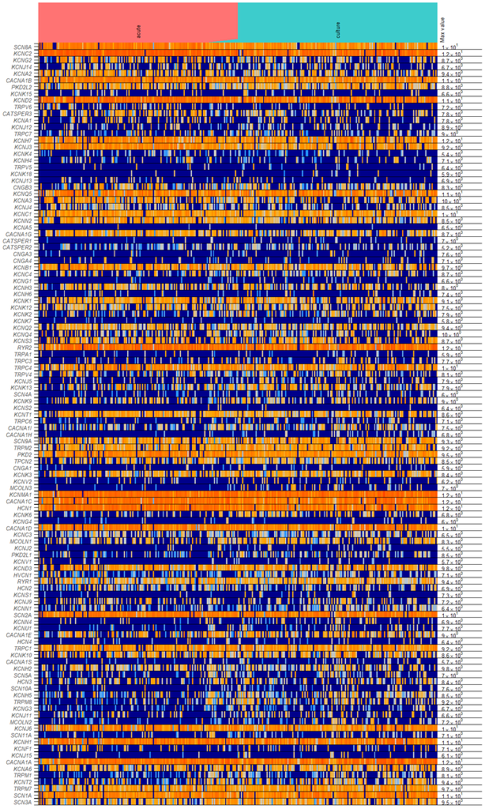

```r
scrattch.vis::sample_heatmap_plot(data_df, anno, genes = gnTmp, grouping = "condition", log_scale = TRUE, font_size = 10, label_height = 5)
dev.off()
```

## Integrate patch-seq and cells using Seurat

In this section we are going to integrate Patch-seq and dissociated cells using Seurat, where we also split patch-seq by acute/culture and immune/non-immune signature. This means that we’ll have a total of 5 groups for the integration and we will use dissociated cells as the reference. First, let’s set up the Seurat object

```r
## Subsample MTG GABAergic data
useCl  <- grepl("Inh ",annoMTG_all$cluster_label) # All GABA types (only "Inh L1 SST CHRNA4" has no mapped patch-seq data)
subs   <- rep("other",dim(datMTG_all)[2])
subs[useCl] <- metaPatch$subclass_label[match(annoMTG_all$cluster_label[useCl],metaPatch$topLeaf_label)]
keepNuclei  <- (subsampleCells(annoMTG_all$cluster_label,10)|subsampleCells(subs,250))&useCl #10 250
lenD   <- sum(keepNuclei)

## Use marker genes from dendrogram as set of genes for integration and UMAP/
markers <- paste(annoPatch$marker_genes,collapse = " ")  # May want to have this as in input file
markers <- strsplit(markers, " ")[[1]]
markers <- intersect(rownames(patch),markers)

## Create data and metadata files
all.data     <- cbind(datMTG_all[,keepNuclei],datPatch[,])
all.metadata <- data.frame( celltype  = c(annoMTG_all$cluster_label[keepNuclei],metaPatch$topLeaf_label),
                            condition = c(rep("dissociated",lenD),metaPatch$condition),
                            condition2= c(rep("dissociated",lenD),metaPatch$condition2),
                            subclass  = c(subs[keepNuclei],metaPatch$subclass_label),
                            source    = c(rep("AIBS",lenD),c("AIBS","other")[grepl("x",metaPatch$cell_specimen_project)+1]),
                            platform  = c(rep("dissociated",lenD),rep("patch-seq",dim(metaPatch)[1])))
rownames(all.metadata) <- colnames(all.data)

## Create Seurat object
all.seurat <- CreateSeuratObject(counts = all.data, meta.data = all.metadata)
```

Next, perform the data integration.

```r
# Split by condition and immune status (e.g.)
patch.list <- SplitObject(object = all.seurat, split.by = "condition2")

# Chose dendrogram markers as integration anchor features
patch_features <- markers

set.seed(10)  # I don't think this is necessary, but just in case...
patch.anchors  <- FindIntegrationAnchors(object.list = patch.list, reference = 1,  # Reference is dissociated cells
                                         verbose=FALSE, anchor.features = patch_features)
```

[output not shown]

```r
# this command creates an 'integrated' data assay
patch.combined <- IntegrateData(anchorset = patch.anchors, verbose=FALSE)
```

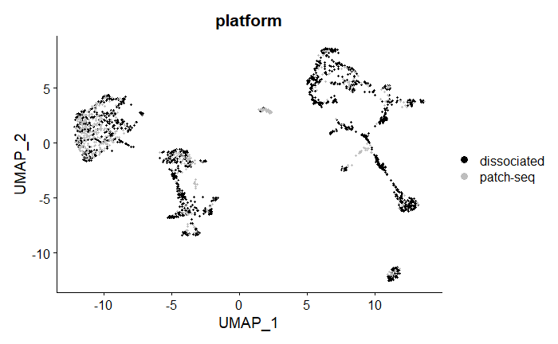

```r
# Perform the integration analysis
DefaultAssay(patch.combined) <- "integrated"

# Calculate UMAP
pcs <- 30
patch.combined <- ScaleData(patch.combined, verbose = FALSE)
patch.combined <- RunPCA(patch.combined, npcs = pcs, verbose = FALSE)
patch.combined <- RunUMAP(patch.combined, reduction = "pca", dims = 1:pcs, verbose = FALSE)

DimPlot(patch.combined, reduction = "umap", group.by = "platform", label = FALSE, cols=c("black","grey"), shuffle=TRUE)
```

Visualize some subclass and cell type plots.

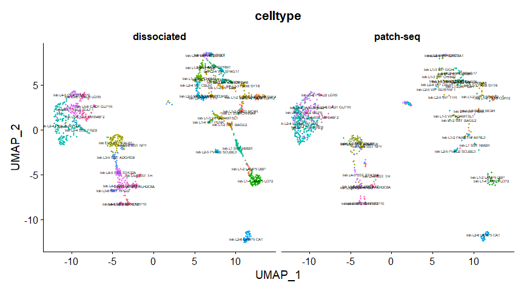

```r
DimPlot(patch.combined, reduction = "umap", group.by = "celltype", split.by = "platform", label = TRUE, label.size = 1.5) + NoLegend()
```

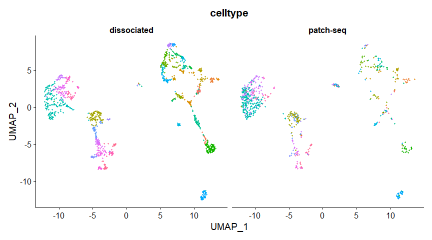

```r
DimPlot(patch.combined, reduction = "umap", group.by = "celltype", split.by = "platform", label = FALSE) + NoLegend()
```

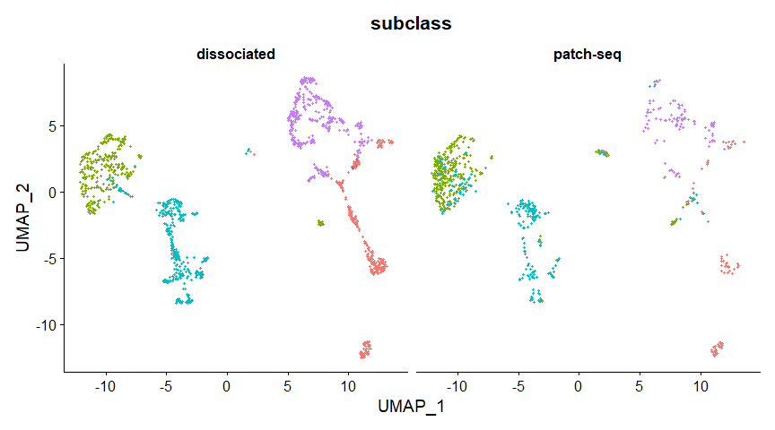

```r
DimPlot(patch.combined, reduction = "umap", split.by = "platform", label = FALSE, group.by="subclass", ncol=2) + NoLegend()
```

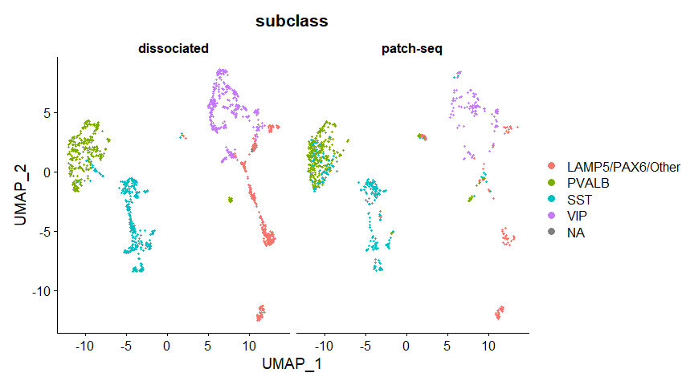

```r
DimPlot(patch.combined, reduction = "umap", split.by = "platform", label = FALSE, group.by="subclass", ncol=2)
```

Save a bunch of umaps for figures in a file.

```r
# Calculate x and y limits
tmp <- FetchData(patch.combined,vars = c("UMAP_1","UMAP_2"))
x1  <- min(tmp[,1])
x2  <- max(tmp[,1])
y1  <- min(tmp[,2])
y2  <- max(tmp[,2])
# Shortcut function
DimPlot2 <- function(x,...)  DimPlot(x,reduction="umap",shuffle=TRUE,...)+xlim(x1,x2)+ylim(y1,y2)

pdf("all_tx_umap_plots.pdf",onefile = TRUE, height = 6, width = 6.5)
DimPlot2(patch.combined, group.by = "platform", label = FALSE, cols=c("black","grey"))
DimPlot2(patch.combined, group.by = "platform", label = FALSE, cols=c("black","grey")) + NoLegend()
```

```r
pso  <- patch.combined$platform=="patch-seq"
subcols <- annoPatch$subclass_color[match(sort(unique(metaPatch$subclass_label)),annoPatch$subclass_label)]
subcols[subcols=="#A64D"] = "#A64D00"
DimPlot2(patch.combined[,!pso], group.by = "subclass", label = TRUE, label.size = 2, cols=subcols) + NoLegend()
DimPlot2(patch.combined[,!pso], group.by = "subclass", label = FALSE, cols=subcols) + NoLegend() + ggtitle("Subclass (dissociated)")
```

```r
DimPlot2(patch.combined[,pso], group.by = "subclass", label = FALSE, cols=subcols) + NoLegend() + ggtitle("Subclass (patch-seq)")

DimPlot2(patch.combined[,pso], group.by = "condition2", label = FALSE)
```

```r
DimPlot2(patch.combined[,pso], group.by = "condition2", label = FALSE) + NoLegend()
DimPlot2(patch.combined[,pso], group.by = "source", label = FALSE)
```

```r
DimPlot2(patch.combined[,pso], group.by = "source", label = FALSE)  + NoLegend()

## Add more metadata for specific plots
# NOTE: source_P and celltype_PS are not needed if we only plot relevant cells
kp_P  <- patch.combined$celltype=="Inh L2-4 PVALB WFDC2"
source_P <- patch.combined$condition
source_P[!kp_P] = NA
patch.combined <- AddMetaData(patch.combined,source_P,"source_P")
kp_PS <- is.element(patch.combined$subclass,c("PVALB","SST"))
celltype_PS <- patch.combined$celltype
celltype_PS[!kp_PS] = NA
patch.combined <- AddMetaData(patch.combined,celltype_PS,"celltype_PS")

DimPlot2(patch.combined[,pso&kp_P], group.by = "source_P", label = FALSE) + ggtitle("Source (Pvalb only)")
```

```r
DimPlot2(patch.combined[,pso&kp_P], group.by = "source_P", label = FALSE) + NoLegend() + ggtitle("Source (Pvalb only)")

typecols <- annoPatch$topLeaf_color[match(sort(unique(patch.combined[,pso&kp_PS]$celltype)),annoPatch$topLeaf_label)]
typecols[nchar(typecols)<7] <-paste0(typecols[nchar(typecols)<7],"00")

DimPlot2(patch.combined[,pso&kp_PS], group.by = "celltype_PS", label = TRUE, label.size = 2, cols=typecols) + NoLegend() + ggtitle("Cell type (Pvalb+Sst)")
```

```r
DimPlot2(patch.combined[,pso&kp_PS], group.by = "celltype_PS", label = FALSE, cols=typecols) + NoLegend() + ggtitle("Cell type (Pvalb+Sst)")

subtype <- patch.combined$subclass
subtype[subtype=="SST"] = "SST other"
subtype[patch.combined$celltype=="Inh L2-4 SST FRZB"] <- "SST FRZB"
tmp <- AddMetaData(patch.combined,subtype,"subtype")
cls <- c("#A64D00", "green", "#CC1FCC") # "#1F1FCC"
DimPlot2(tmp[,pso&kp_PS], group.by = "subtype", label = TRUE, label.size = 2, cols=cls) + NoLegend() + ggtitle("Types (Pvalb+Sst)")
```

```r
DimPlot2(tmp[,pso&kp_PS], group.by = "subtype", label = FALSE, cols=cls) + NoLegend() + ggtitle("Types (Pvalb+Sst)")

dev.off()
```

There is generally good integration between patch-seq and FACS overall, with the exception of ~10% of cells that seem to cluster separately and likely represent low quality transcriptomics data.

How do things look post-integration?

```r
patch.combined_noDis <- patch.combined[,patch.combined$condition2!="dissociated"]
DimPlot(patch.combined_noDis, reduction = "umap", split.by = "condition2", label = FALSE, group.by="subclass", ncol=2)

pdf("post_integration_UMAP_split.pdf",height=6,width=8)
```

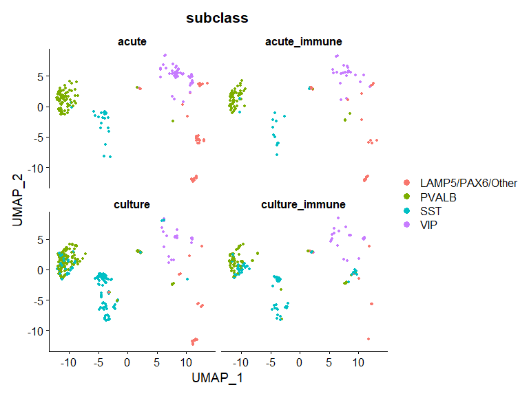

```r
DimPlot(patch.combined_noDis, reduction = "umap", split.by = "condition2", label = FALSE, group.by="subclass", ncol=2)
dev.off()
```

## Perform mapping a different way

One question that came up is how robust is the choice of cell-typing method to cell type selection. We used a tree-mapping approach to assign cell types (calculated prior to running this script). As a sanity check, we compare cell type assignments from that approach with cell types assigned through a simple correlation-based mapping approach.

```r
props     <- get_cl_prop(datMTG_all,clMTG)
betaScore <- sort(getBetaScore(props[setdiff(names(keepGenes)[keepGenes],is_immune),kpClusts], returnScore = FALSE))
top.genes <- names(betaScore)[1:250]

cors       <- corTreeMapping(datPatch[top.genes,],medians[top.genes,])
cor_clusts <- getTopMatch(cors[,kpClusts])

pred_celltypes <- cor_clusts[colnames(datPatch),"TopLeaf"]
mean(pred_celltypes==metaPatch$topLeaf_label)
```

```
[1] 0.5989717
```

```r
pred_subs <- metaPatch$subclass_label[match(pred_celltypes,metaPatch$topLeaf_label)]
pred_subs[is.na(pred_subs)] = "PVALB"
mean(pred_subs==metaPatch$subclass_label)
```

```
[1] 0.9061697
```

```r
table(pred_subs,metaPatch$subclass_label)
```

```
pred_subs          LAMP5/PAX6/Other PVALB SST VIP
  LAMP5/PAX6/Other               81     1   0   2
  PVALB                           3   298  31   0
  SST                             1    26 216   0
  VIP                             7     2   0 110
```

```r
ctmp <- c("Inh L2-4 PVALB WFDC2","Inh L2-4 SST FRZB")
table(pred_celltypes,metaPatch$topLeaf_label)[ctmp,ctmp]
```

```
pred_celltypes         Inh L2-4 PVALB WFDC2 Inh L2-4 SST FRZB
  Inh L2-4 PVALB WFDC2                  141                20
  Inh L2-4 SST FRZB                      11                48
```

```r
for (tmp in c("LAMP5/PAX6/Other", "PVALB", "SST", "VIP")){
  kp <- (pred_subs==tmp)&(metaPatch$subclass_label==tmp)
  print(paste(tmp,"-",signif(mean(pred_celltypes[kp]==metaPatch$topLeaf_label[kp]),3)))
}
```

```
[1] "LAMP5/PAX6/Other - 0.889"
[1] "PVALB - 0.695"
[1] "SST - 0.639"
[1] "VIP - 0.445"
```

Plot the confusion between types.

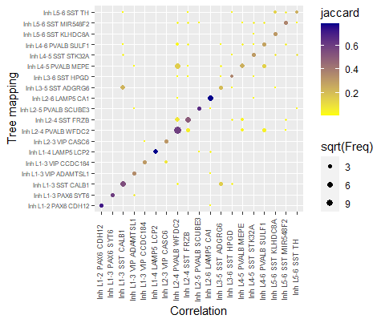

```r
compare_plot <- function (cl, ref.cl)
{
    names(cl) <- names(ref.cl) <- paste0("i",1:length(cl))
    common.cells <- intersect(names(cl), names(ref.cl))
    tb <- table(cl[common.cells], ref.cl[common.cells])
    tb.df <- as.data.frame(tb)
    tb.df <- tb.df[tb.df$Freq > 0, ]
    select.cells <- names(cl)
    tb.df$jaccard <- 0
    for (i in 1:nrow(tb.df)) {
        n_ol <- length(union(common.cells[cl[common.cells] ==
            as.character(tb.df[i, 1])], common.cells[ref.cl[common.cells] ==
            as.character(tb.df[i, 2])]))
        tb.df$jaccard[i] <- tb.df$Freq[i]/n_ol
    }
    colnames(tb.df) <- c("cl", "ref.cl", "Freq",
        "jaccard")
    g <- ggplot2::ggplot(tb.df, ggplot2::aes(x = cl, y = ref.cl)) +
        ggplot2::geom_point(aes(size = sqrt(Freq), color = jaccard)) +
        ggplot2::theme(axis.text.x = ggplot2::element_text(vjust = 0.1,
            hjust = 0.2, angle = 90, size = 7), axis.text.y = ggplot2::element_text(size = 6)) +
        ggplot2::scale_color_gradient(low = "yellow", high = "darkblue") +
        ggplot2::scale_size(range = c(0, 3))
    g
}

compare_plot(factor(pred_celltypes,levels=kpClusts),
                               factor(metaPatch$topLeaf_label,levels=kpClusts)) +
                                 xlab("Correlation") +
                                 ylab("Tree mapping")
```

## Abundance comparison

Another question that came up is whether there is a change in abundance of cells of given types selected in the culture system, which may represent a bias in either sampling or in the DLX promoter to identify cells of particular types. First less assess what proportion of cells come from each subclass in each condition. We’ll need to recalculate these values for FACS since we subsampled.

```r
prop_metadata <- cbind(patch.combined$condition2,patch.combined$subclass,patch.combined$celltype)
colnames(prop_metadata) <- c("condition2","subclass","celltype")
prop_metadata <- prop_metadata[prop_metadata[,"condition2"]!="dissociated",]
prop_metadata <- as.data.frame(prop_metadata)

annoTmp <- cbind("dissociated",prop_metadata$subclass[match(annoMTG_all$cluster_label,prop_metadata$celltype)],
                 annoMTG_all$cluster_label)
annoTmp <- annoTmp[!is.na(annoTmp[,2]),]
colnames(annoTmp) <- colnames(prop_metadata)
prop_metadata <- rbind(prop_metadata,annoTmp)
```

For the cell types included in this study, how do the subclass proportions compare?

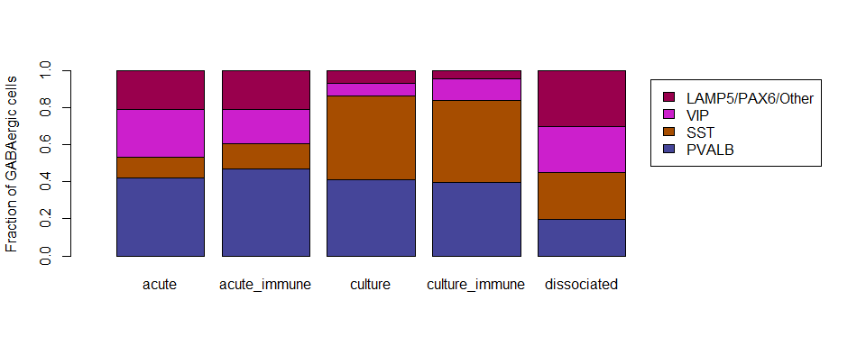

```r
countsSubclass <- table(prop_metadata$condition2,prop_metadata$subclass)
fracsSubclass  <- t(countsSubclass/rowSums(countsSubclass) )
barplot(fracsSubclass[c(2,3,4,1),], legend=TRUE,xlim=c(0,8), col=subcols, ylab="Fraction of GABAergic cells")

par(mar=c(2,20,2,2))
```

```r
countsSubclass <- table(gsub("_immune","",prop_metadata$condition2),prop_metadata$subclass)
fracsSubclass  <- t(countsSubclass/rowSums(countsSubclass) )
barplot(fracsSubclass[c(2,3,4,1),], legend=TRUE,xlim=c(0,6), col=subcols, ylab="Fraction of GABAergic cells")

pdf("subclass_acuteVsCultureVsDissociated_barplot.pdf", height=4, width=10)
```

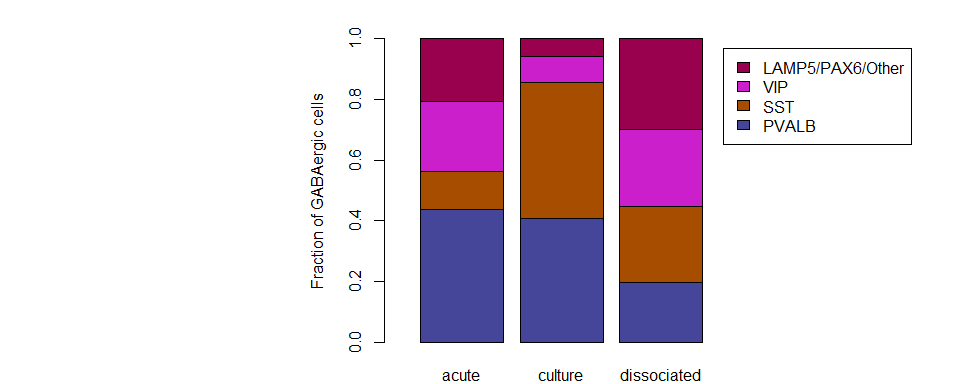

```r
par(mar=c(2,20,2,2))
barplot(fracsSubclass[c(2,3,4,1),], legend=TRUE,xlim=c(0,6), col=subcols, ylab="Fraction of GABAergic cells")
dev.off()
```

There are a few things to note here. First, there is no obvious difference in subclasses that display or don’t display the immune signature. Second, the acute preparation has a lower fraction of SST cells than in Hodge et al 2019. This is known and was one of the primary drivers to pursuing a culture prep in the first place. Finally, the culture prep has more SST cells and many fewer CGE cells. This is likely due to a combination of purposeful bias of cell selection of patch-seq operators, as well as any potential biases in the DLX promoter.

How does this look at the cell type level?

```r
par(mfrow=c(2,2))
for (s in unique(prop_metadata$subclass)){
  kp <- prop_metadata$subclass==s
  countsCelltype <- table(gsub("_immune","",prop_metadata$condition2[kp]),prop_metadata$celltype[kp])
  fracsCelltype  <- t(countsCelltype/rowSums(countsCelltype) )
  barplot(fracsCelltype, legend=TRUE,xlim=c(0,6.5),col=WGCNA::standardColors(), ylab=paste("Fraction of",s,"cells"))
}
pdf("celltype_acuteVsCultureVsDissociated_barplot.pdf", height=10, width=12)
```

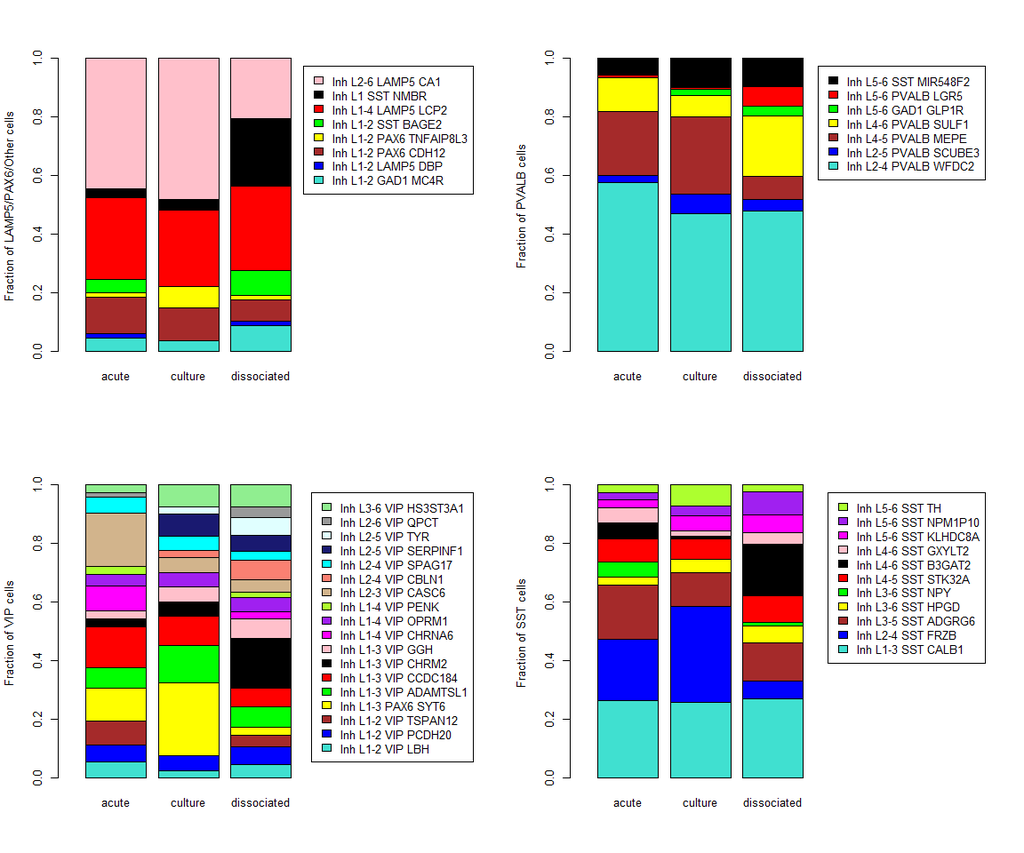

```r
par(mfrow=c(2,2))
for (s in unique(prop_metadata$subclass)){
  kp <- prop_metadata$subclass==s
  countsCelltype <- table(gsub("_immune","",prop_metadata$condition2[kp]),prop_metadata$celltype[kp])
  fracsCelltype  <- t(countsCelltype/rowSums(countsCelltype) )
  barplot(fracsCelltype, legend=TRUE,xlim=c(0,6.5),col=WGCNA::standardColors(), ylab=paste("Fraction of",s,"cells"))
}
dev.off()
```

## Plotting without data integration

One question came up about whether we are using the optimal strategy for data integration. To address this we show that a few results hold without data integration. First, let’s plot a UMAP of our results based on marker genes without data integration.

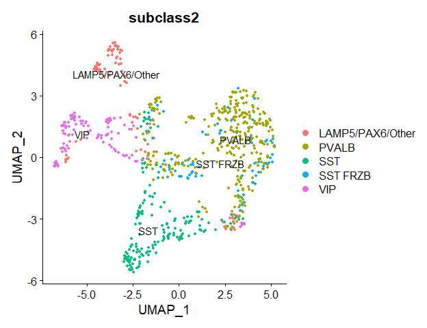

```r
all.marker <- all.seurat[markers,all.seurat$condition2!="dissociated"]
VariableFeatures(all.marker) <- markers
pcs <- 30
all.marker <- ScaleData(all.marker, verbose = FALSE)
all.marker <- RunPCA(all.marker, npcs = pcs, verbose = FALSE)
all.marker <- RunUMAP(all.marker, reduction = "pca", dims = 1:pcs, verbose = FALSE)

all.marker$subclass2 <- all.marker$subclass
all.marker$subclass2[all.marker$celltype=="Inh L2-4 SST FRZB"] = "SST FRZB"

DimPlot(all.marker, reduction = "umap", group.by = "subclass2", label = TRUE, shuffle=TRUE)
```

```r
DimPlot(all.marker, reduction = "umap", group.by = "condition2", label = FALSE, shuffle=TRUE)

pdf("subclass_no_integration_using_markers.pdf",height=6,width=8)
```

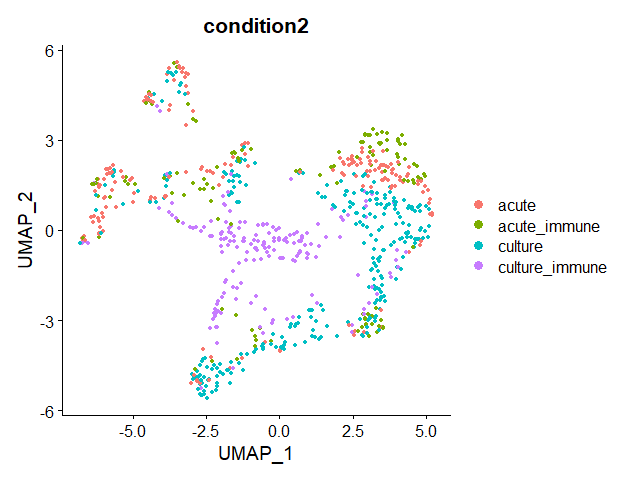

```r
DimPlot(all.marker, reduction = "umap", group.by = "subclass", label = FALSE, shuffle=TRUE,
        cols = c("#DB7193","#B12324","#FAA51A","#7D277D"), pt.size = 2)
dev.off()
```

Overall there is reasonable separation by subclass. Next let’s see where SST FRZB clusters separately by condition2 when considering only each condition2 separately and only looking at SST or PVALB cells.

```r
p   <- list()
pcs <- 30
for (d in unique(all.seurat$condition2)){
  kp <- (all.seurat$condition2==d)&is.element(all.seurat$subclass,c("SST","PVALB"))
  all.marker <- all.seurat[setdiff(names(keepGenes)[keepGenes],is_immune),kp]
  all.marker <- FindVariableFeatures(all.marker, verbose = FALSE)
  all.marker <- ScaleData(all.marker, verbose = FALSE)
  all.marker <- RunPCA(all.marker, npcs = pcs, verbose = FALSE)
  all.marker <- RunUMAP(all.marker, reduction = "pca", dims = 1:pcs, verbose = FALSE)
  all.marker$subclass2 <- all.marker$subclass
  all.marker$subclass2[all.marker$celltype=="Inh L2-4 SST FRZB"] = "SST FRZB"

  p[[d]] <- DimPlot(all.marker, reduction = "umap", group.by = "subclass2", label = TRUE, shuffle=TRUE, pt.size=2) + ggtitle(d)
}
```

|  | t | l | b | r |
| --- | --- | --- | --- | --- |
| 1: | 1 | 1 | 1 | 1 |

|  | t | l | b | r |
| --- | --- | --- | --- | --- |
| 1: | 1 | 1 | 1 | 1 |

|  | t | l | b | r |
| --- | --- | --- | --- | --- |
| 1: | 1 | 1 | 1 | 1 |

|  | t | l | b | r |
| --- | --- | --- | --- | --- |
| 1: | 1 | 1 | 1 | 1 |

|  | t | l | b | r |
| --- | --- | --- | --- | --- |
| 1: | 1 | 1 | 1 | 1 |

```r
gridExtra::grid.arrange(p[[1]],p[[2]],p[[3]],p[[4]],p[[5]],ncol=3)
pdf("no_data_integration_MGE.pdf",height = 6, width=12)
```

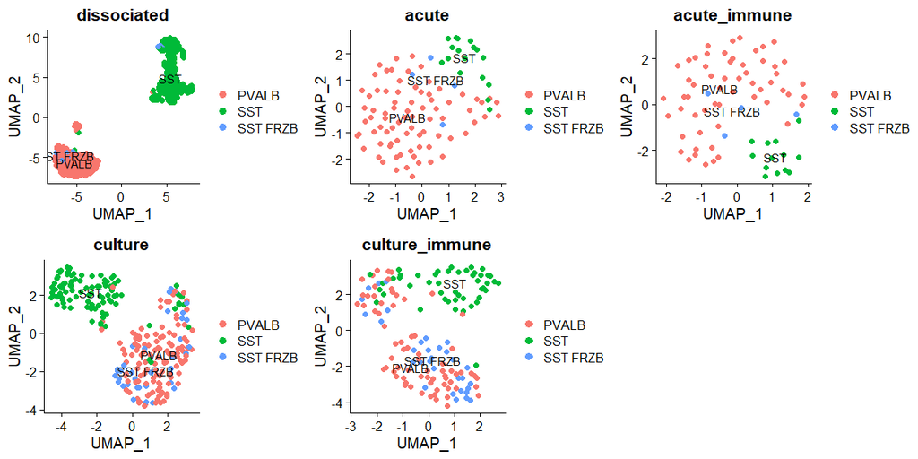

```r
gridExtra::grid.arrange(p[[1]],p[[2]],p[[3]],p[[4]],p[[5]],ncol=3)
dev.off() # Close the file
```

## Compare genes and mapping confidences in acute/culture and immune/not

First, let’s look at mapping confidence between the two groups (culture non-immune, vs culture immune) - is it the same?

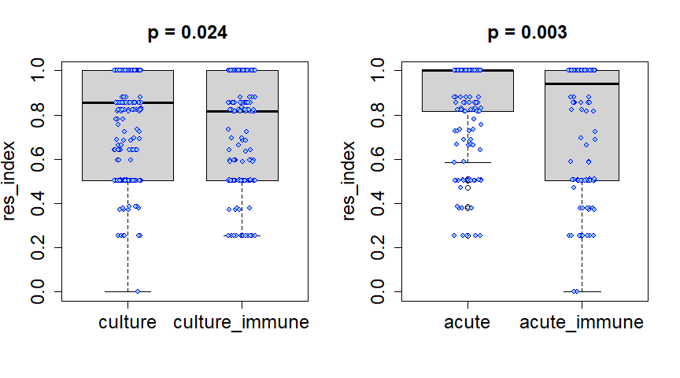

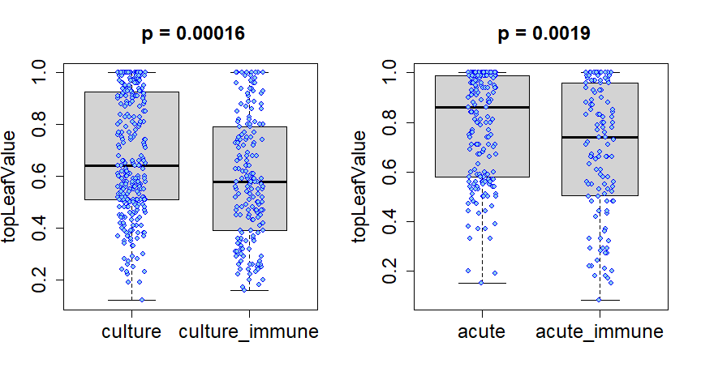

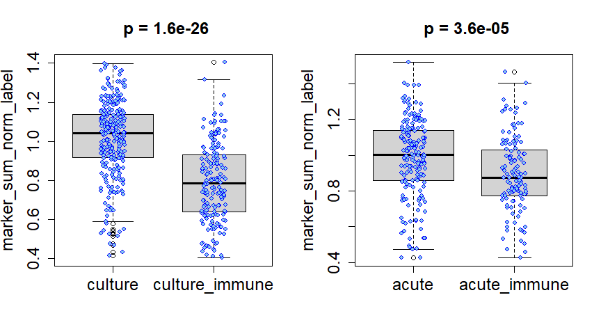

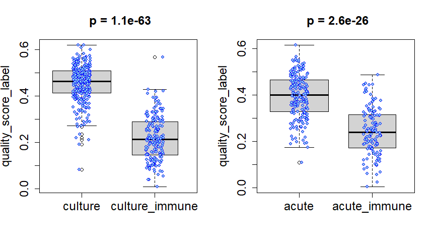

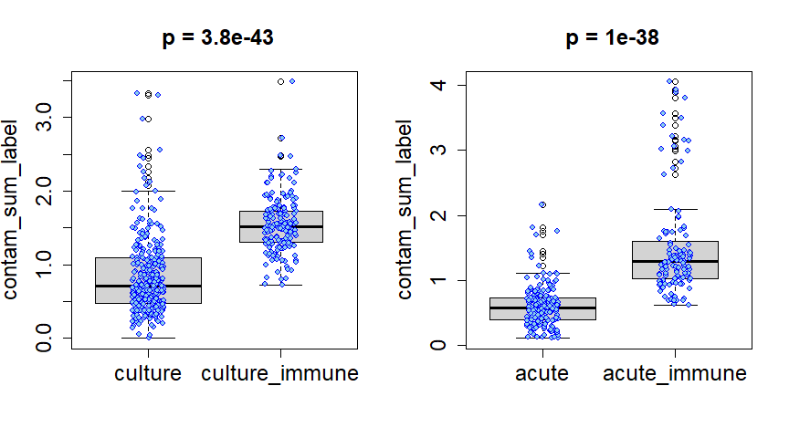

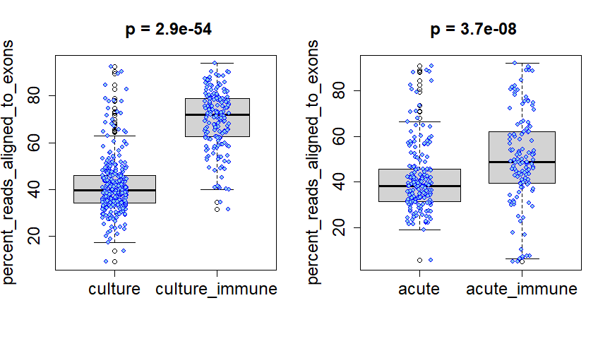

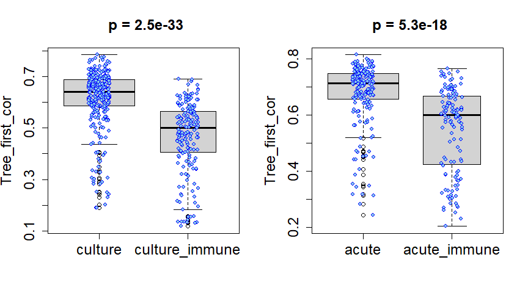

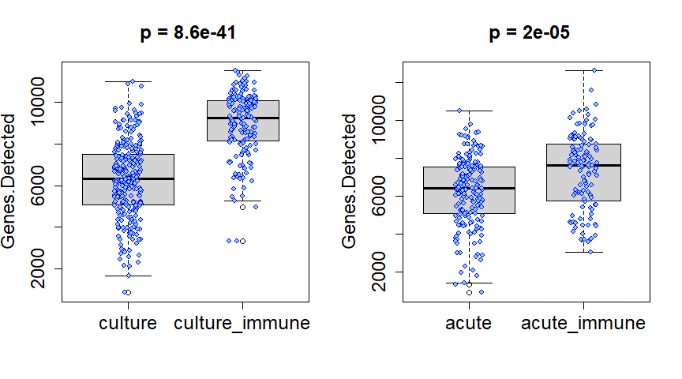

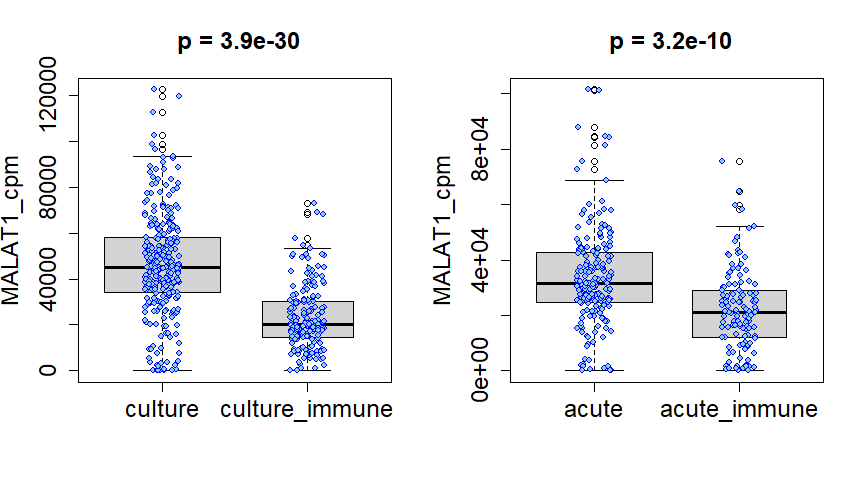

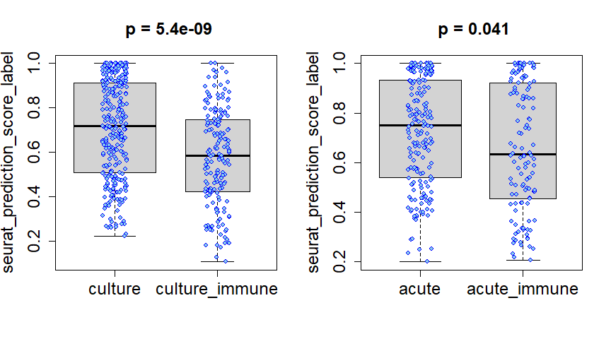

```r
metaPatch$seurat_prediction_score_label <- annoPatch$seurat_prediction_score_label
metaPatch$contam_sum_label <- annoPatch$contam_sum_label
cols <- c("res_index","topLeafValue","marker_sum_norm_label","quality_score_label", "contam_sum_label",
          "percent_reads_aligned_to_exons","Tree_first_cor",
          "Genes.Detected","MALAT1_cpm","seurat_prediction_score_label")
par(mfrow=c(1,2))
for (col in cols){
  kpc <- grepl("culture",patch$condition2)&(!is.na(metaPatch[,col]))
  kpa <- (!grepl("culture",patch$condition2))&(!is.na(metaPatch[,col]))
  verboseBoxplot(metaPatch[,col][kpc],patch$condition2[kpc], notch=FALSE, xlab="", ylab=col,addScatterplot = TRUE)
  verboseBoxplot(metaPatch[,col][kpa],patch$condition2[kpa], notch=FALSE, xlab="", ylab=col,addScatterplot = TRUE)
}
```

```r
table(metaPatch$Tree_call,patch$condition2)
```

```
        acute acute_immune culture culture_immune
  Core     83           34      84             23
  I1       44           32      61             33
  I2       36           16      90             28
  I3        1            1       9              4
  PoorQ    24           41      44             90
```

```r
table(annoPatch$contaminationType_label,patch$condition2)
```

```
              acute acute_immune culture culture_immune
  Astrocyte      23            3      36              2
  Endothelial    45           13     204              6
  Microglia     108          107      30            170
  Oligo.OPC      12            1      18              0
```

There is a significant difference in every metric between the immune and non-immune cases; however, the metrics related to resolution index are the most similar, suggesting a minimal effect in mapping. It’s worth noting that different runs of the code have different resolution indexes, but the results are generally consistent.